# Advanced Data Wrangling

2025-09-08

## Course Check-in

- **Where We Are:** We’ve covered the basics of R, data wrangling with `dplyr` and `tidyr`, and exploratory data analysis with `ggplot2`.
- **Why This Matters:** Real-world data is messy. Today’s topics are crucial for preparing data for analysis and modeling.
- **Topics Today:**
  - Dates and Times
  - String Manipulation
  - Handling Missing Values

## R Packages We’ll Use Today

- `tidyverse`: Our go-to collection of packages, including `dplyr` and `ggplot2`.
- `lubridate`: Makes working with dates and times a breeze.
- `stringr`: Provides a consistent, simple interface for string manipulation.
- `naniar`: A powerful package for visualizing and summarizing missing data.

## Working with Dates and Times

- **Why Dates & Times Are Tricky:** R stores dates and times in specific classes (`Date`, `POSIXct`, `POSIXlt`). Raw data often imports as character strings, which can’t be used for calculations.
- **Solution:** The `lubridate` package helps convert strings to proper date and time objects, making them usable for analysis.

## Parsing Dates in R

- The `lubridate` package provides intuitive functions for parsing dates from strings. `ymd()`, `mdy()`, and `dmy()` automatically detect the date format.

```r
# Create a character vector of dates
date_strings <- c("2023-01-15", "02/20/2023", "March 25, 2023", "15-Jan-2023")

# Convert strings to Date objects
dates_ymd <- ymd(date_strings[1])
dates_mdy <- mdy(date_strings[2])
dates_mdy_full <- mdy(date_strings[3])
dates_dmy <- dmy(date_strings[4])

# What is the class of our new variables?
class(dates_ymd)
## [1] "Date"
dates_ymd
## [1] "2023-01-15"
dates_mdy
## [1] "2023-02-20"
dates_mdy_full
## [1] "2023-03-25"
dates_dmy
## [1] "2023-01-15"
```

## Parsing Times in R

- Similarly, functions like `ymd_hms()` and `ymd_hm()` handle timestamps, converting them to `POSIXct` objects that can be used for calculations.

```r
# Create a character vector of timestamps
time_strings <- c("2023-01-15 10:30:00", "2023-02-20 14:05:30", "2023/03/01 09:00 AM")

# Convert strings to POSIXct objects
timestamps_ymd_hms <- ymd_hms(time_strings[1])
timestamps_ymd_hms2 <- ymd_hms(time_strings[2])
timestamps_ymd_hm_am <- ymd_hm(time_strings[3], tz = "America/Los_Angeles")

# Calculate the difference in time
diff_in_minutes <- difftime(timestamps_ymd_hms2, timestamps_ymd_hms, units = "mins")

# What is the difference?
diff_in_minutes
## Time difference of 52055.5 mins

# We can also add time zones
timestamps_ymd_hm_am
## [1] "2023-03-01 09:00:00 PST"
```

## Time Intervals, Durations, and Periods

- **Intervals:** A variable that represents the time between two specific date-times (`interval()`).
- **Durations:** An exact measured amount of time, measured in seconds (`ddays()`).
- **Periods:** A human-friendly time span that respects calendar changes (`days()`).
- **When to use?** Durations for fixed time spans, Periods for calendar-aware arithmetic.

```r
# Example for intervals
start_time <- ymd_hms("2023-01-01 12:00:00")
end_time <- ymd_hms("2023-01-01 13:30:00")

# Create an interval
time_interval <- interval(start_time, end_time)
time_interval
## [1] 2023-01-01 12:00:00 UTC--2023-01-01 13:30:00 UTC

# Get the length of the interval in seconds
as.duration(time_interval)
## [1] "5400s (~1.5 hours)"
```

## Live Example: Periods vs. Durations

- Durations and Periods can behave differently
- Typically adding a “month” means increasing the month number by one
  - but what happens when the new month has fewer days?
  - Need to use `%m+%` when you would get invalid date
- Example where month number stays the same

```r
my_date <- ymd_hms("2024-02-28 12:00:00")
my_date + dmonths(1) # Adds an average number of days
## [1] "2024-03-29 22:30:00 UTC"
my_date + months(1) # Adds exactly a month
## [1] "2024-03-28 12:00:00 UTC"
```

- Example where month number changes

```r
my_date <- ymd_hms("2024-01-31 12:00:00")
my_date + dmonths(1) # Adds an average number of days
## [1] "2024-03-01 22:30:00 UTC"
my_date + months(1) # Error because 2-31 doesn't exist
## [1] NA
my_date %m+% months(1) # Correctly moves to end of Feb
## [1] "2024-02-29 12:00:00 UTC"
```

## Extracting Parts of a Date/Time

- Use functions like `year()`, `month()`, `week()`, `day()`, `hour()`, `minute()`, and `wday()` to extract specific components from a date or time object.

```r
# Extract the month and day of the week
day_of_week <- wday(timestamps_ymd_hms, label = TRUE)
month_of_year <- month(timestamps_ymd_hms, label = TRUE, abbr = FALSE)

# Let's add them to a data frame
df_time_components <- tibble(
    timestamps = timestamps_ymd_hms,
    day = day_of_week,
    month = month_of_year,
    week = week(timestamps_ymd_hms),
    hour = hour(timestamps_ymd_hms),
    minute = minute(timestamps_ymd_hms)
)
df_time_components
## # A tibble: 1 × 6
##   timestamps          day   month    week  hour minute
##   <dttm>              <ord> <ord>   <dbl> <int>  <int>
## 1 2023-01-15 10:30:00 Sun   January     3    10     30
```

## String Manipulation with `stringr`

- **The Problem:** Text data is often unstructured and requires cleaning.
- **The Solution:** The `stringr` package provides a consistent and simple interface for string manipulation, using powerful regular expressions.

## `str_detect()` and `str_replace()`

- `str_detect()` checks if a string contains a pattern.
- `str_replace()` replaces a pattern with a new string.

```r
# Create a vector of text
messages <- c("Error: File not found", "Success: Data loaded", "Warning: Check parameters", "error in line 5")

# Detect which messages contain "error" (case-insensitive)
has_error_ci <- str_detect(messages, regex("error", ignore_case = TRUE))
has_error_ci
## [1]  TRUE FALSE FALSE  TRUE

# Replace "Error" with "Failure"
new_messages <- str_replace(messages, "Error", "Failure")
new_messages
## [1] "Failure: File not found"   "Success: Data loaded"
## [3] "Warning: Check parameters" "error in line 5"
```

## `str_sub()` and `str_c()`

- `str_sub()` extract parts of a string.
  - arguments are `start` and `end` that give the position of string you want to extract
- `str_c()` combines multiple strings together.

```r
# Extract the numeric portion of a product code
product_codes <- c("Product-123-US", "Product-456-JPN", "Product-789-CAN")
extracted_ids <- str_sub(product_codes, 9,11)
extracted_ids
## [1] "123" "456" "789"

# Combine first and last names
first_names <- c("John", "Jane", "Peter")
last_names <- c("Doe", "Smith", "Jones")
full_names <- str_c(first_names, last_names, sep = " ")
full_names
## [1] "John Doe"    "Jane Smith"  "Peter Jones"
```

## Cleaning and Transforming Strings

- `stringr` offers many functions to quickly clean and standardize text data.

```r
# Strings with extra whitespace
messy_strings <- c("  Hello World  ", " R is great! ")
str_trim(messy_strings)
## [1] "Hello World" "R is great!"

# Convert case
names_mixed <- c("Alice", "bOB", "CHARLIE")
str_to_lower(names_mixed)
## [1] "alice"   "bob"     "charlie"
str_to_upper(names_mixed)
## [1] "ALICE"   "BOB"     "CHARLIE"
```

## Advanced Regex for Strings

- Regular expressions (regex) are a powerful language for pattern matching in strings.
- **Common Patterns:**
  - `.` : Any character
  - `\d`: Any digit
  - `\s`: Any whitespace
  - `*`: Zero or more
  - `+`: One or more
  - `?`: Zero or one
  - `^`: Start of string
  - `$`: End of string

## Live Example: Advanced Regex

```r
# Extract all numbers from a string
text_with_numbers <- "The price is $12.50, and quantity is 100. Item codes: A-23, B-45."
numbers <- str_extract_all(text_with_numbers, "\\d+")
numbers
## [[1]]
## [1] "12"  "50"  "100" "23"  "45"

# Extract email addresses
email_list <- c("user1@example.com", "info@domain.net", "no_email_here", "contact.us@sub.domain.org")
emails_found <- str_extract(email_list, "[A-Za-z0-9._%+-]+@[A-Za-z0-9.-]+\\.[A-Za-z]{2,}")
emails_found
## [1] "user1@example.com"         "info@domain.net"
## [3] NA                          "contact.us@sub.domain.org"
```

## Handling Missing Values

- **The Problem:** Missing data (`NA`) can cause errors or skew our analysis.
- **The Solution:** We must understand and handle missing values appropriately, whether by removing them, imputing them, or converting other indicators to `NA`.

## Summarizing Missing Data

- The `naniar` package provides helpful tools to visualize and summarize missing values

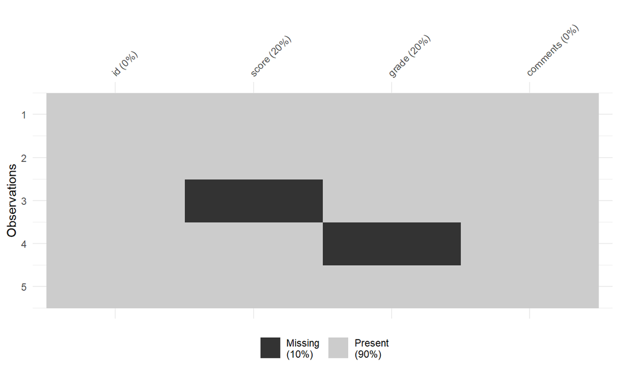

```r
# Create a data frame with missing values
missing_df <- tibble(id = 1:5,score = c(85, 92, NA, 78, 88),grade = c("A", "B", "C", NA, "B"), comments = c("Good", "Excellent", "N/A", "Needs work", "OK"))

# See the missing data structure
vis_miss(missing_df)
```

## `na_if()` to Convert Values

- Use `na_if()` from `dplyr` to convert specific strings (like “N/A”, “Unknown”) to `NA` so R can properly recognize them as missing values.

```r
# Data with "N/A" as a missing indicator
data_with_na_strings <- tibble(
  product = c("A", "B", "C"),
  price = c(100, 150, NA),
  availability = c("In Stock", "Out of Stock", "N/A")
)

# Convert "N/A" to NA
cleaned_data <- data_with_na_strings %>%
  mutate(availability = na_if(availability, "N/A"))

cleaned_data
## # A tibble: 3 × 3
##   product price availability
##   <chr>   <dbl> <chr>
## 1 A         100 In Stock
## 2 B         150 Out of Stock
## 3 C          NA <NA>
```

## Visualizing Missing Data Patterns

- `naniar` provides functions like `gg_miss_upset()` to visualize the patterns of missingness, helping us understand if values are missing at random or if there’s a relationship between missingness in different variables.

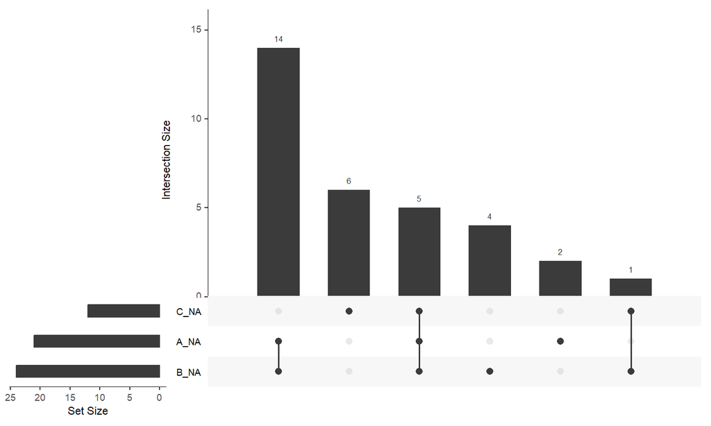

```r
# Visualize missing data patterns
gg_miss_upset(correlated_missing_df)
```

## Summary: Dates & Times

- Use `lubridate` to parse, manipulate, and extract components from dates and times.
- Understand the difference between **Intervals**, **Durations**, and **Periods** for accurate time-based calculations.

## Summary: Strings & Missing Values

- Use `stringr` for consistent, powerful text manipulation.
- Use `naniar` and `dplyr`/`tidyr` to understand and handle missing values.

## What’s Next?

- **Day 8:** Feature Engineering! We will use the skills we learned today to create new variables and transform our data to improve our models.